# Prosper Loan Data EDA

```
## loan$LoanStatusLabel: Completed
##    Min. 1st Qu.  Median    Mean 3rd Qu.    Max.    NA's
##  0.0000  0.0000  0.0000  0.5958  0.0000 50.0000     463
## --------------------------------------------------------
## loan$LoanStatusLabel: Failed
##    Min. 1st Qu.  Median    Mean 3rd Qu.    Max.    NA's
##   0.000   0.000   0.000   1.602   1.000  83.000     233
```

Mean of CurrentDelinquencies for Colpleted loans is 0.6 and this number is 1.6 for failed loans. CurrentDelinquencies is a powerful predictor for failing a loan.

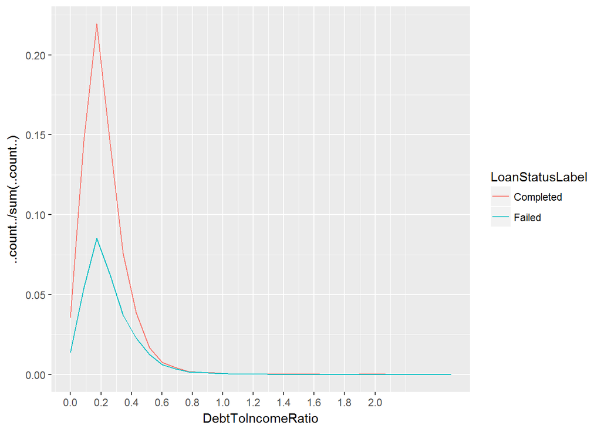

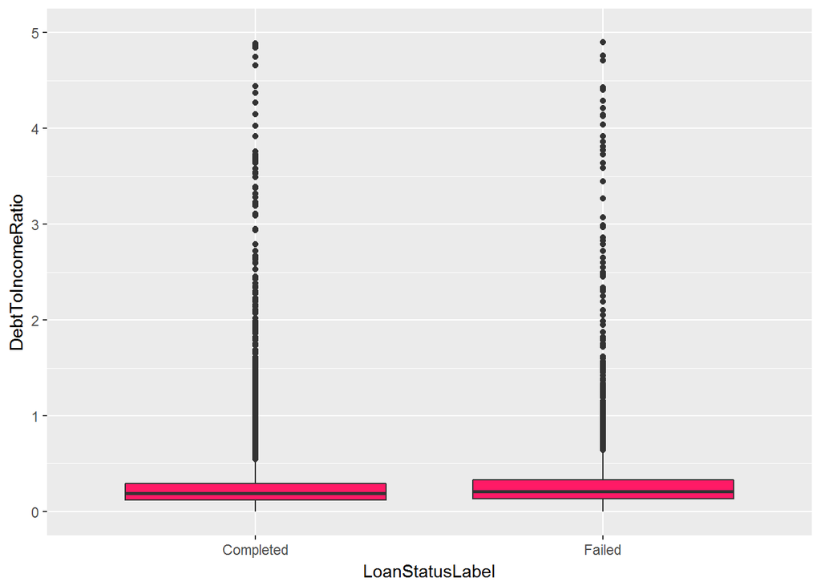

```
## loan$LoanStatusLabel: Completed
##    Min. 1st Qu.  Median    Mean 3rd Qu.    Max.    NA's
##  0.0000  0.1200  0.1900  0.2642  0.2900 10.0100    2734
## --------------------------------------------------------
## loan$LoanStatusLabel: Failed
##    Min. 1st Qu.  Median    Mean 3rd Qu.    Max.    NA's
##  0.0000  0.1393  0.2200  0.3484  0.3300 10.0100    1496
```

So DebtToIncomeRatio is another good predictor for loan status.

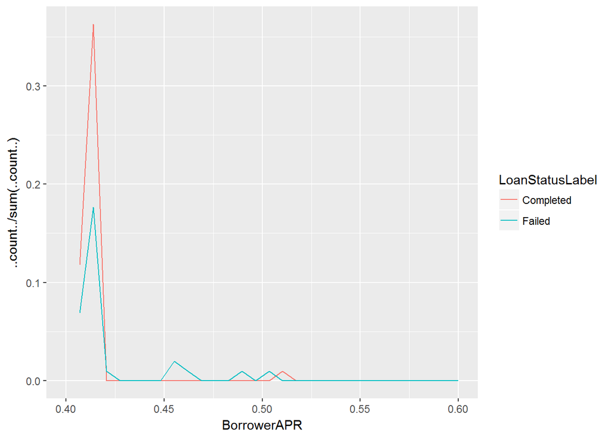

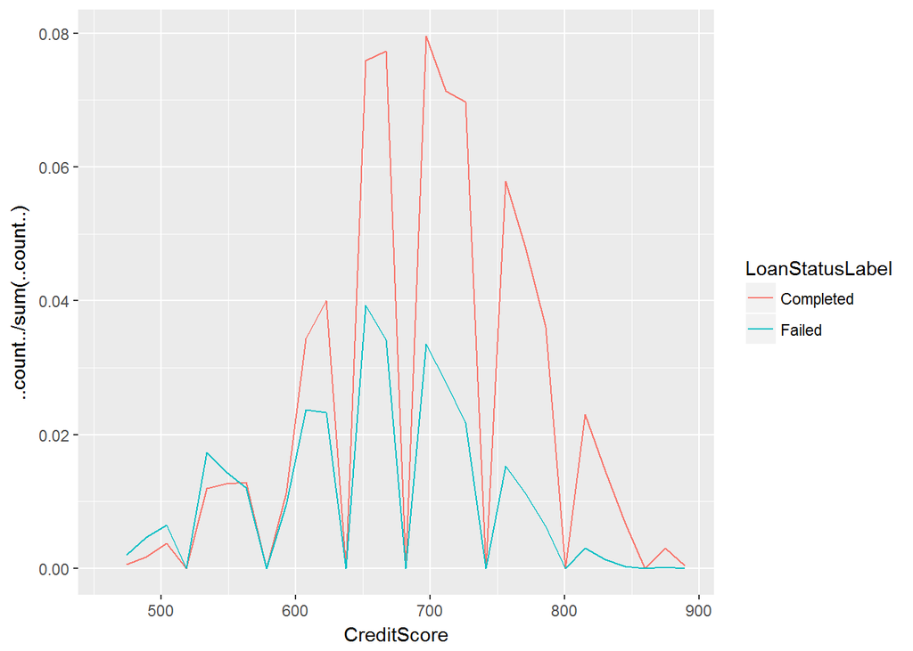

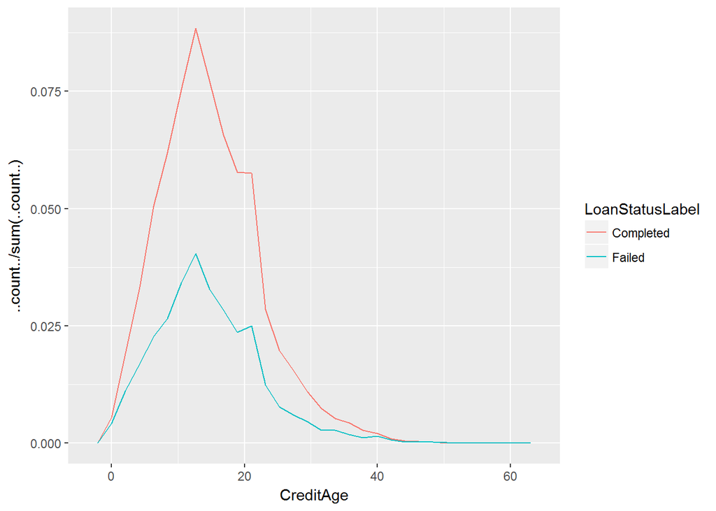

```
##
## Completed    Failed
##         1         6
```

It seems like most of loans with APR more than 0.45 failed.

```
## # A tibble: 2 x 4
##   LoanStatusLabel CreditAge_mean CreditAge_median     n
##            <fctr>          <dbl>            <dbl> <int>
## 1       Completed       14.77661               14 38074
## 2          Failed       14.46605               13 17010
```

The difference between CreditAge mean and median for 2 group of LoanStatusLabel of interest (Completed and Failed) is not very significant.

```
## # A tibble: 2 x 4
##   LoanStatusLabel creditScore_mean CreditScore_median     n
##            <fctr>            <dbl>              <dbl> <int>
## 1       Completed         695.5871                690 38074
## 2          Failed         650.7876                650 17010
```

The median CreditScore for Completed and Failed LoanStatusLables has 40 points difference.

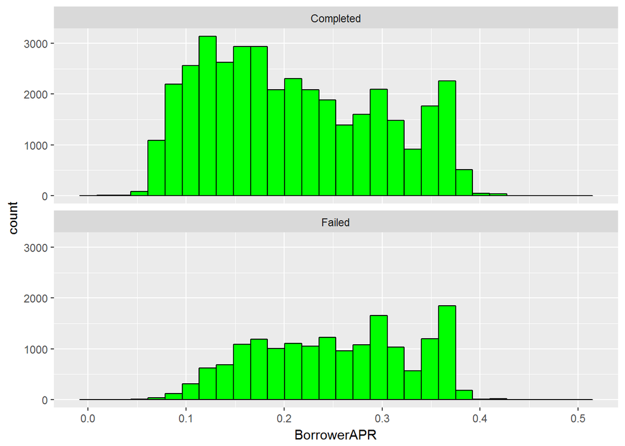

The distribution of different result for LoanStatusLabel in BorrowerAPR shows that Completed loans are a little right skewed and Faild loans are roughly uniformly distributed. It means most of the failed loans relativly had larger APRs.

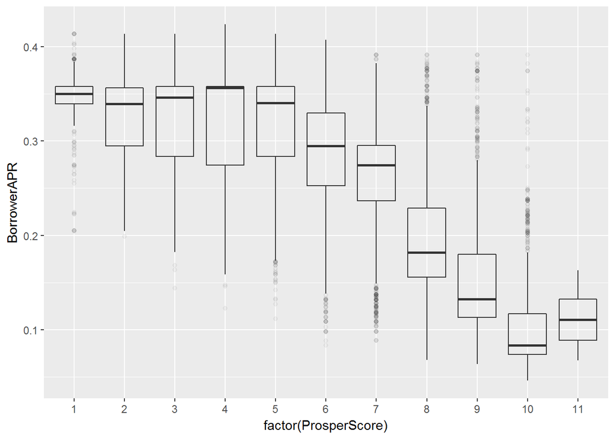

The ProsperScore and BorrowerAPR are negatively correlated with -0.74 Correlation Coefficient. That’s a strong correlation.

```
## [1] -0.7380842
```

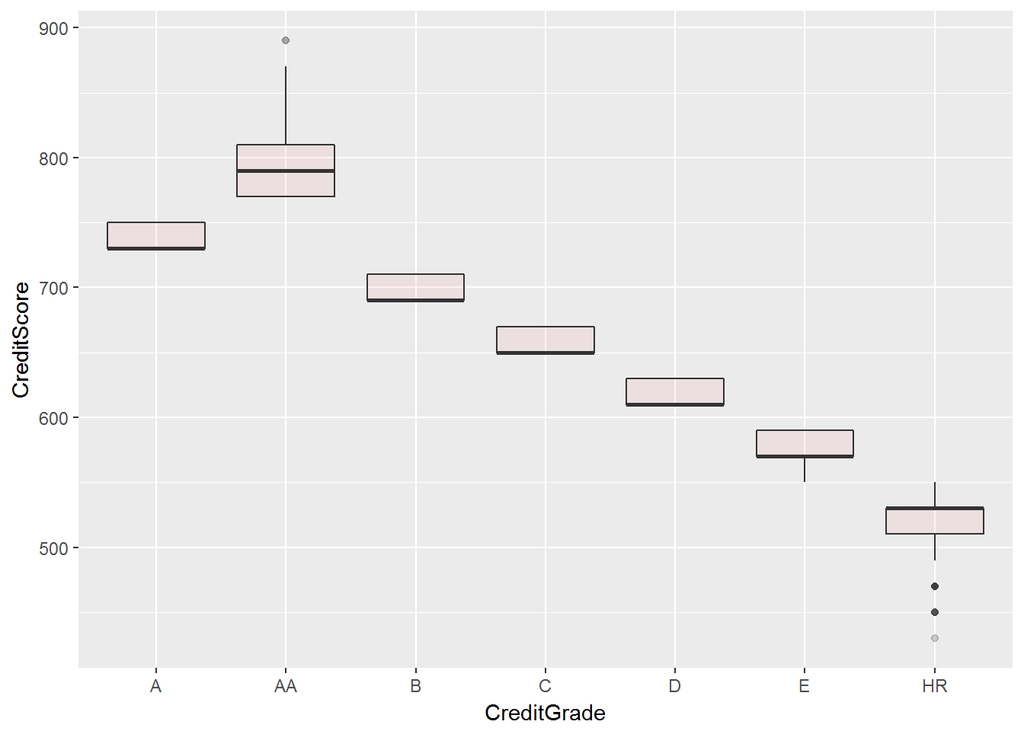

There are many overlaps, so I am using Jitter to see more clearly.

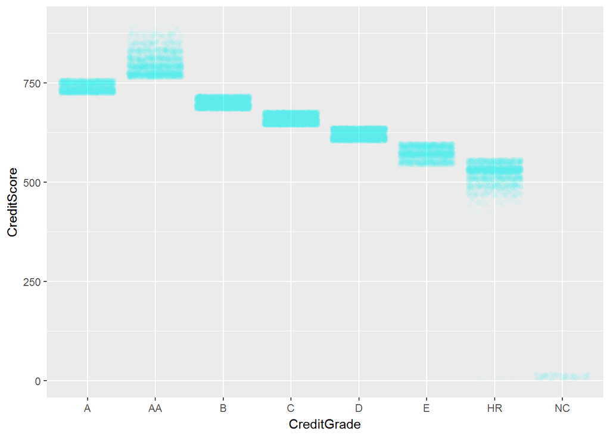

It seems like CreditGrades are implemented base on CreditScore.

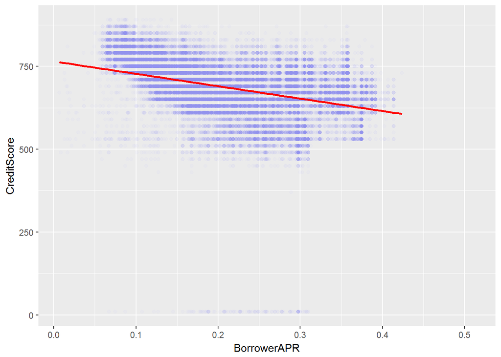

There is a negative correlation between BorrowerAPR and CreditScore:

```
## [1] -0.4022054
```

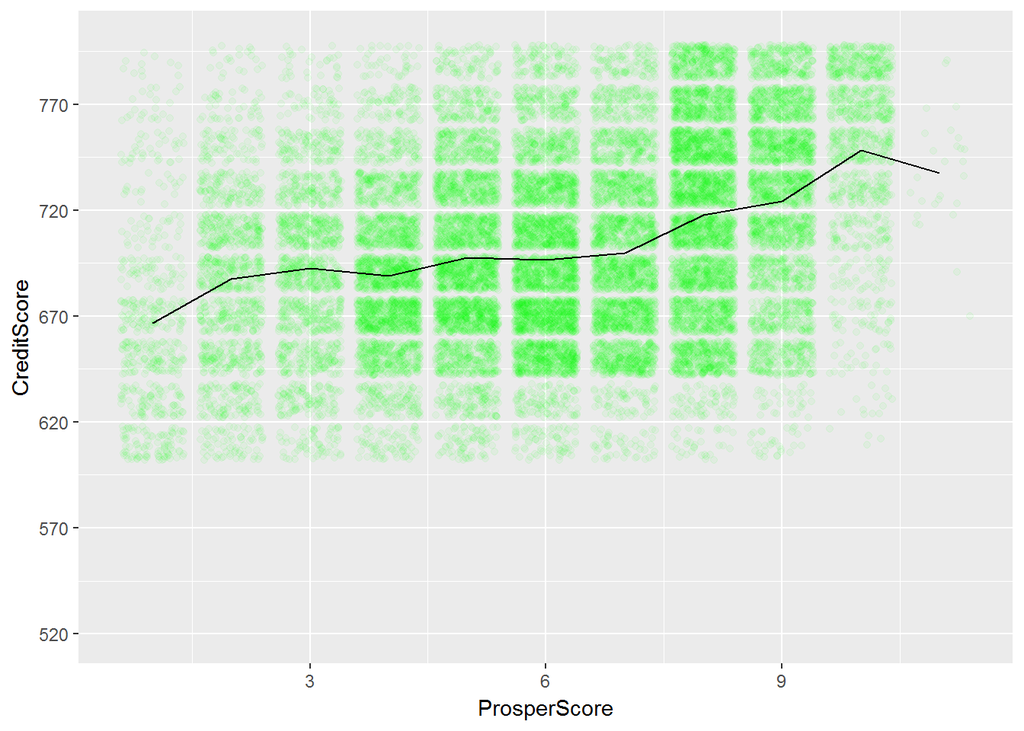

ProsperScore and CreditScore variables are positively correlated; The correlation coefficient is:

```
## [1] 0.3967875
```

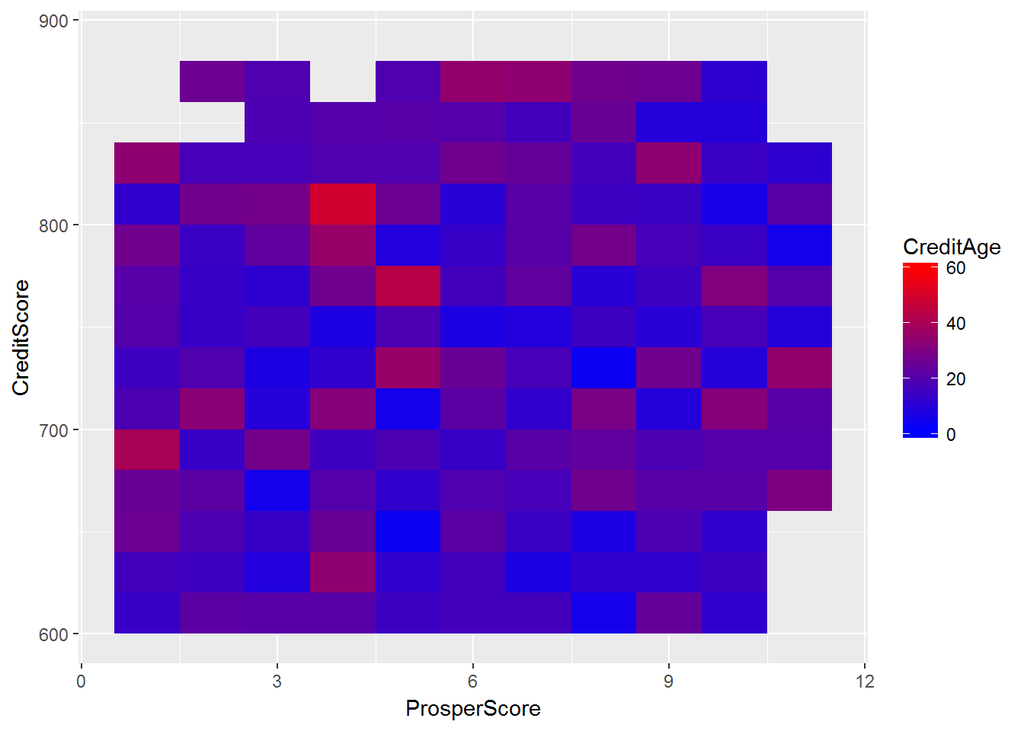

Term and LoanOriginalAmount:

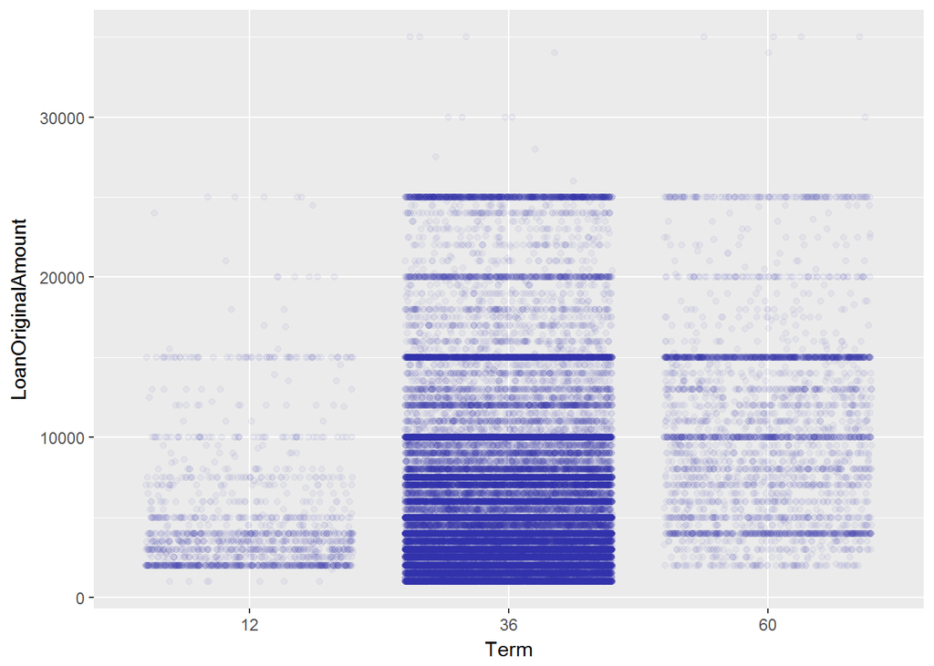

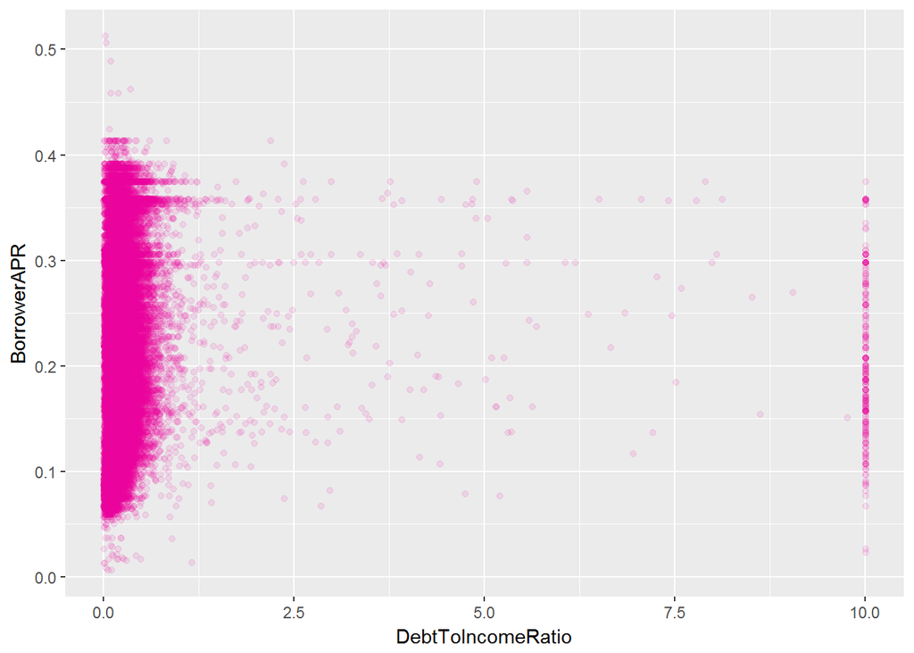

Correlation between DebtToIncomeRatio and BorrowerAPR:

```
## [1] 0.03053818
```

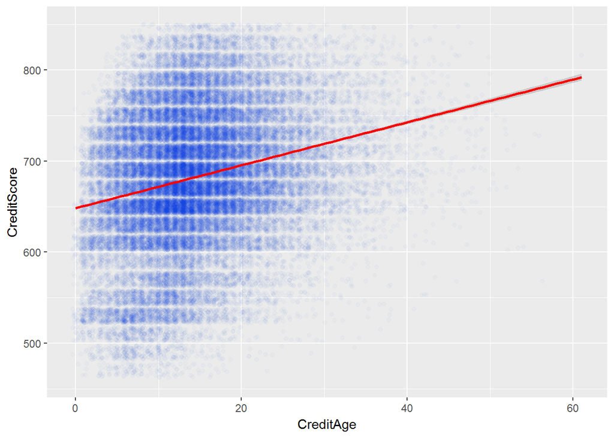

Correlation between CreditAge and CreditScore:

```
## [1] 0.2445919
```

# Bivariate Analysis

### Talk about some of the relationships you observed in this part of the

### investigation. How did the feature of interest vary with other features

### in the dataset?

- Lower BorrowerAPR has a bigger change of being a Completed loan rather than the larger BorrowerAPRs. The majority of completed loans have BorrowerAPR less than 0.2
- Borrowers with more CurrentDelinquencies are more likely to fail a loan rather than borrowers with zero number of CurrentDelinquencies.
- Borrower that complete their loan, has a bigger proportion of larger CreditScore rather than failed loan borrowers.

### Did you observe any interesting relationships between the other features

### (not the main feature of interest)?

There are some strong relationships between CreditScore and many other variables like: BankcardUtilization, DebtToIncomeRatio, CurrentDelinquencies. It makes sense. Because CreditScore is a function of many of these variables. On the other hand ProsperScore has good correlation with CreditScore, and it should be because they both have same features for creation.

### What was the strongest relationship you found?

The strongest correlation is between ProsperScore and BorrowerAPR with correlation coefficient equal to -0.73; That’s maybe related to this fact that one of the main patameters for determining BorrowerAPR is ProsperScore;

# Multivariate Plots Section

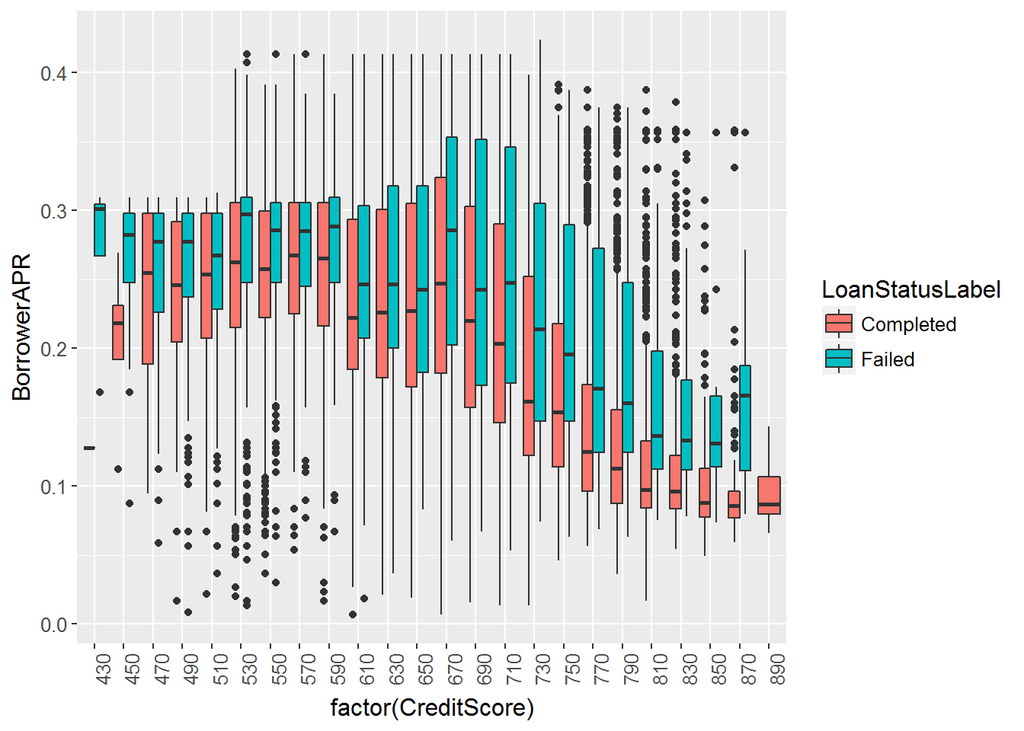

That’s interesting; Without exception, average APR for borrowers with same CreditScore is more for Failed loans!

```
##
## Completed    Failed
##      2584       256
```

```
##
## Completed    Failed
##       373       842
```

Above 90% of debtors with creditScore more than 810, are Completed their Loan and the majority(69%) of debtors with CreditScore under 510, failed their loan.

```
##
## Completed    Failed
##      4166       412
```

Loans with DebtToIncomeRatio less than 0.5 with ProsperScore more than 8 is very likely to complete(91%).

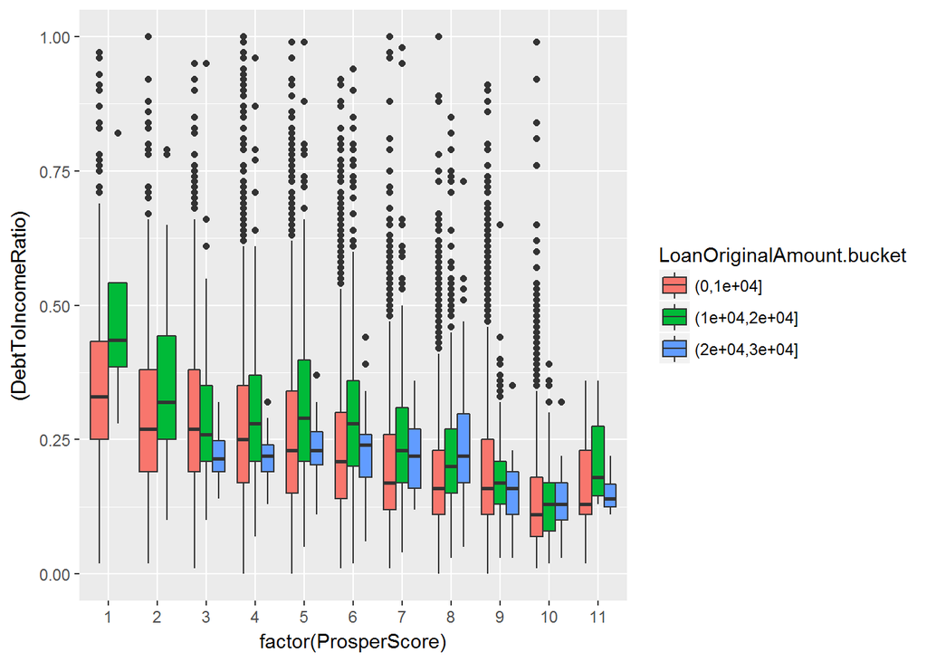

When DebtToIncomeRatio decreases, the ProsperScore increases; For ProsperScore less than 3, there is no LoanOriginalAmount greater than 20000.

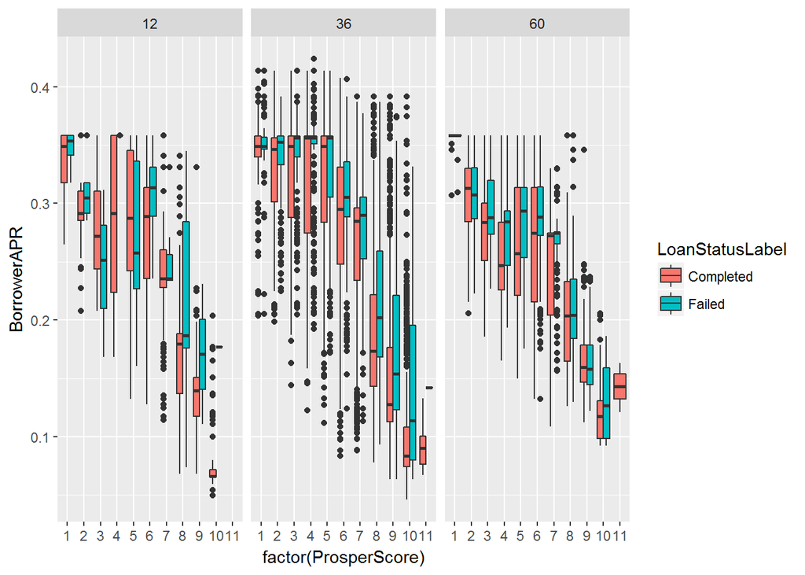

```
##
## Completed    Failed
##       650        12
```

The most successful loans has 12 months Term with BorrowerAPR less than 0.2 and Employed or Fulltime job borrower; 98% of these loans are Completed.

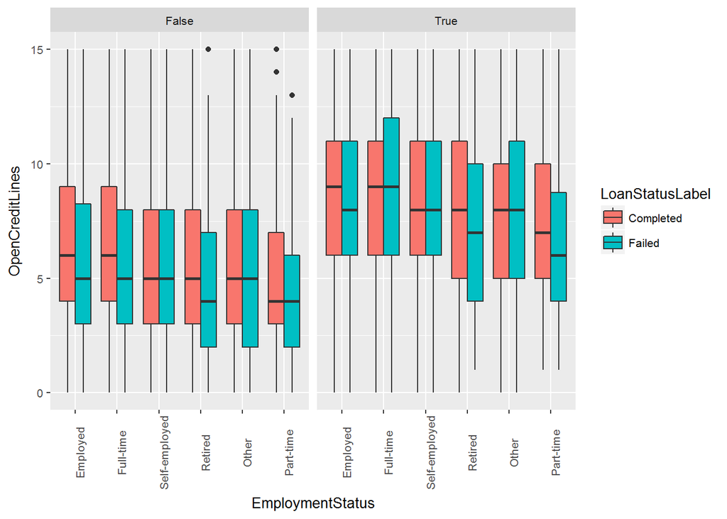

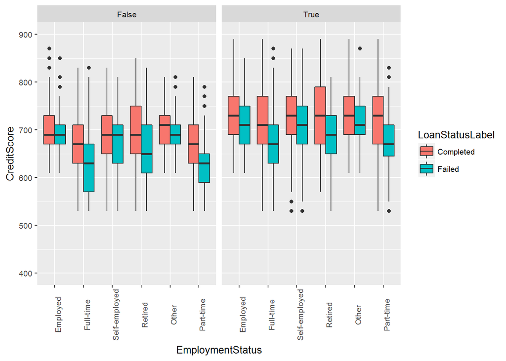

HomeOwners has larger margings for CreditSCore and if they are Employed or Fulltime job, it’s more likely to complete their loan.

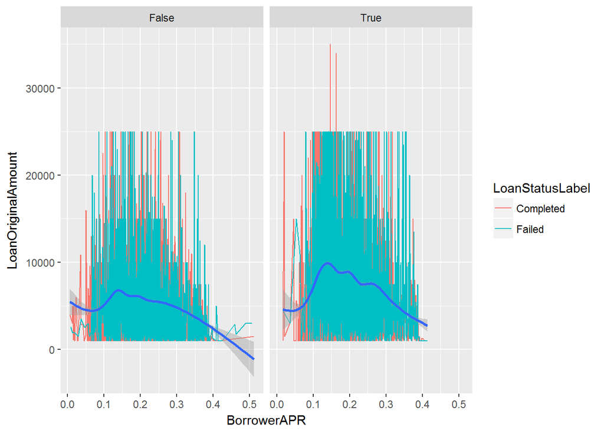

```
##
## False  True
##   880  1829
```

In general HomeOwners are qualified for larger loans and the percentage of their failure is more than not HomeOwners.

# Multivariate Analysis

### Talk about some of the relationships you observed in this part of the

### investigation. Were there features that strengthened each other in terms of

### looking at your feature of interest?

Terms of loans and BorrowerAPR and EmploymentStatus are creat a good predictor for LoanStatusLabel. e.g. a loan with 12 months Term and APR less than 0.2 for a borrower that is Employed or has Fulltime job is very likely to complete.

### Were there any interesting or surprising interactions between features?

HomeOwners with Original Loan amount more than 10000 are more likely to fail thier prosper loan rather than not HomeOwners the ratio is 67%.

### OPTIONAL: Did you create any models with your dataset? Discuss the

### strengths and limitations of your model.

I think with some of these features we can train a classifier for predicting Completed of Failed loans. ——

# Final Plots and Summary

### Plot One

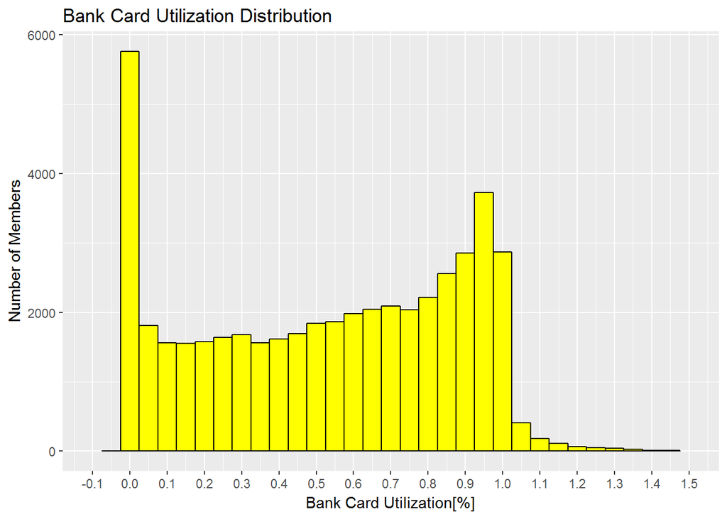

### Description One

It’s a bimodal distribution. Many of members have 0 revolving bank card utilization and the second crowded point is 0.95 utilization. It’s interesting because there are two peaks in two sides of the spectrum. The first quartile is 0.21 and mean of this variable is 0.53. The maximun value of this variable is 5.95;

### Plot Two

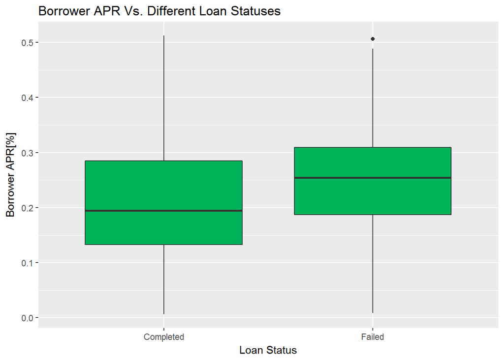

```
##
## Completed    Failed
##     19638      5062
```

### Plot Three

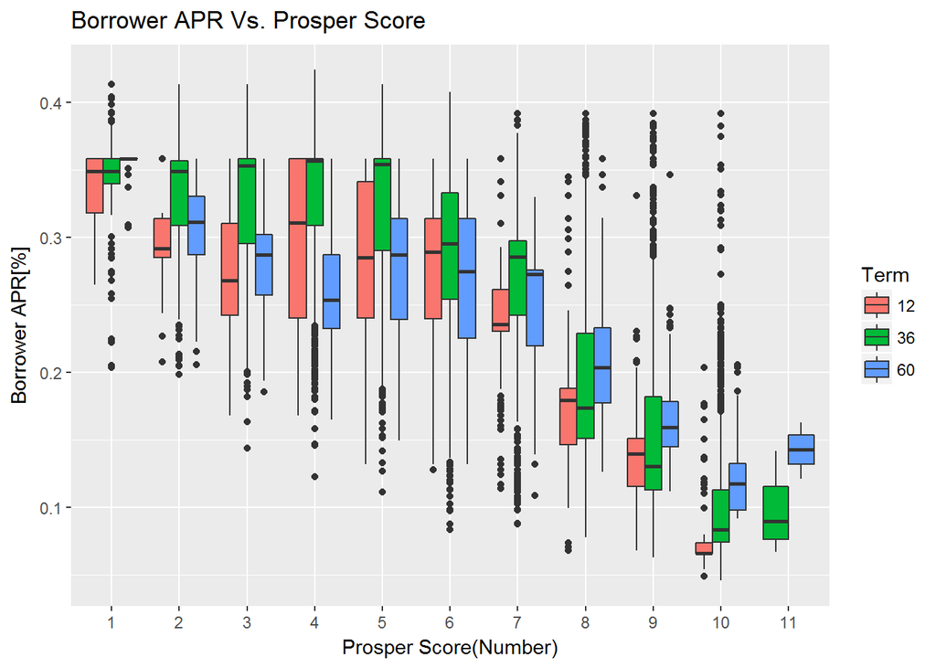

```
##
## Completed    Failed
##       650        12
```

### Description Three

The most successful loans have 12 months Term. On the other hand 80% of loans with Borrower APR less than 0.2 are completed. Another important parameter is Employment status. Best categories for Employment Status are Employed and Full-time. If we add up all these conditions together the loans will have 98% chance of being completed. That’s a really high chance. There are 16491 borrower that are Employed and 24957 borrower has Full-time job; Very few of borrowers are not employed: 561; It makes sense because when Prosper choose somebody to offer a loan, they prefer that person has some kind of job; ——

# Reflection

The Prosper loan data set contains 113,937 clients with 81 variables. I choose 16 variables and focus on specific categories and I found 55084 clients in the new dataset. Some variables are related to scoring clients. Variables like CreditScore, ProsperScore, CreditGrade. These scores has close relationship together.

I was struggling how I choose a handful of variables between 81  
variables from the original dataset. I choose the most independent and not IDs and gradually decrease them till I reach 16 of them. Another problem was the dataset has null values for NAs and it takes a while to understand why I can not filterout NAs with !is.na(variable). Another thing that I made decision about was LoanStatus variable. It contain many different categories and after considering them, I understand I only need two labels for loans: Completed or Failed and the other categories are not finished and I can not use them as label.

I believe finding main features for predicting the loan status is a great success. And my graphs show how strong these features predict the loan status. This is important for implementing the classifier for future research. Defining CreditAge and CreditScore as two new variables are another success of this study. Finding the importance of Borrower APR from different aspects, is another success that I personally like it.

The process I went through has these stages: First I investigate each variable distribution and used some transformations for changing some non-normal distributions. Next I investigate the relationship and correlations between different features. Gradually I defined the project goal, finding the most important predictors for successfull loans or Completed ones. I realize that The BorrowerAPR and Terms of loan and ProsperScore and Employment Status are good predictors for categorizing loans in Completed and Failed groups.

The next step base on these findings could be training a decision tree or naive bayes classifier base on mentioned fetures for Loas Status as target.

Some limitation of this proccess should be the size of the filtered dataset. Because I only focus on Completed and Failed loan statuses and I can not more than 50% of the original dataset because those loans results are not finished and they are in progress. If I have access to the updated dataset, I should use all original datapoints for training and testing purposes and that really help when I double size of dataset.